# modulo1_preprocesado_datos_R_Manuel_Berea_Arellano

# Evalución 2025 - Módulo 1 - Preprocesado de datos

Manuel Berea Arellano En el siguiente cuaderno estarán todos los ejercicios pedidos en R para Preprocesado de datos.

```r
R.version.string
```

```
## [1] "R version 4.3.2 (2023-10-31 ucrt)"
```

```r
library(arrow)
```

```r
library(tidyverse) ## dplyr, ggplot, etc.
library(skimr)
library(DataExplorer)
library(gridExtra)
library(solitude)
library(corrplot)
library(minerva)
library(DescTools)
library(mice)
library(sampling)
library(formattable)
# Configuración de dimensiones de los gráficos
knitr::opts_chunk$set(fig.width = 20, fig.height = 16)
```

## Prepocesado de datos

Cargamos los datos

```r
path <- "~/Universidad/Master Uned/Master_Uned/Modulo 1/parkinsons_disease_data.parquet"
df <- as.data.frame(read_parquet(path))
head(df)
```

```
##   PatientID Age Gender Ethnicity EducationLevel      BMI Smoking
## 1      3058  85      0         3              1 19.61988       0
## 2      3059  75      0         0              2 16.24734       1
## 3      3060  70      1         0              0 15.36824       0
## 4      3061  52      0         0              0 15.45456       0
## 5      3062  87      0         0              1 18.61604       0
## 6      3063  68      1         2              1 39.42331       1
##   AlcoholConsumption PhysicalActivity DietQuality SleepQuality
## 1           5.108241        1.3806599    3.893969     9.283194
## 2           6.027648        8.4098041    8.513428     5.602470
## 3           2.242135        0.2132746    6.498805     9.929824
## 4           5.997788        1.3750452    6.715033     4.196189
## 5           9.775243        1.1886071    4.657572     9.363925
## 6          13.596889        7.7967040    7.070239     7.737549
##   FamilyHistoryParkinsons TraumaticBrainInjury Hypertension Diabetes Depression
```

[output cut: 34 more lines]

### 1. Análisis exploratorio de datos (EDA)

Vamos a dividir este primer apartado en varios puntos: - Análisis descriptivo - Análisis de relacción entre variables

#### 1.1 Análisis descriptivo

En este primer apartado queremos ver que cantidad de observaciones tenemos, cuantas variables, de que tipo son, etc. En caso de ser necesario haremos un cambio del tipo de variable en este punto, ya que la inferencia de esquema no siempre funciona correctamente, sobre todo con variables categoricas que tienen valor numerico.

```r
glimpse(df)    # Ver estructura de las columnas
```

```
## Rows: 2,105
## Columns: 33
## $ PatientID                <int> 3058, 3059, 3060, 3061, 3062, 3063, 3064, 306…
## $ Age                      <int> 85, 75, 70, 52, 87, 68, 78, 70, 80, 71, 70, 5…
## $ Gender                   <int> 0, 0, 1, 0, 0, 1, 1, 1, 0, 0, NA, 0, 0, 1, 0,…
## $ Ethnicity                <int> 3, 0, 0, 0, 0, 2, 0, 0, 2, 3, 0, 0, 2, 1, 0, …
## $ EducationLevel           <int> 1, 2, 0, 0, 1, 1, 0, 0, 1, 2, 3, 1, 2, 2, 3, …
## $ BMI                      <dbl> 19.61988, 16.24734, 15.36824, 15.45456, 18.61…
## $ Smoking                  <int> 0, 1, 0, 0, 0, 1, 1, 1, 1, 1, 0, 1, 0, 0, 1, …
## $ AlcoholConsumption       <dbl> 5.1082406, 6.0276480, 2.2421353, 5.9977876, 9…
## $ PhysicalActivity         <dbl> 1.3806599, 8.4098041, 0.2132746, 1.3750452, 1…
## $ DietQuality              <dbl> 3.893969, 8.513428, 6.498805, 6.715033, 4.657…
## $ SleepQuality             <dbl> 9.283194, 5.602470, 9.929824, 4.196189, 9.363…
## $ FamilyHistoryParkinsons  <int> 0, 0, 0, 0, 0, 0, 0, 0, 0, 0, 0, 0, 0, 0, 0, …
## $ TraumaticBrainInjury     <int> 0, 0, 0, 0, 0, 0, 0, 0, 0, 1, 0, 0, 0, 0, 0, …
```

[output cut: 20 more lines]

Con la función glimpse podemos mirar la dimensión, el nombre de las columnas, el tipo de variable y algun valor ejemplo que nos encontramos en las primeras observaciones. Utilizando esta función ya podemos ver que hay variables que aparecen como INT y en realidad son variables categoricas. A continuación vamos a cambiar a variables categoricas que las que lo deben ser y veremos con skim una primera visión del conjunto de datos.

```r
# Las variables que deben de ser factor
variables_factor <- c("Gender","Ethnicity","EducationLevel","Smoking","FamilyHistoryParkinsons","TraumaticBrainInjury","Hypertension","Diabetes","Depression","Stroke","Tremor","Rigidity","Bradykinesia","PosturalInstability","SpeechProblems","SleepDisorders","Constipation","Diagnosis")
variables_numeric <- setdiff(names(df), variables_factor)

df <- df %>%
        mutate_at(vars(variables_factor), as.factor) %>%
        mutate(PatientID = paste0("P_",PatientID)) # Modificamos la variable ID para que no sea numérica.
variables_numeric <- variables_numeric[-which(variables_numeric == "PatientID")]
variables_factor <- variables_factor[-which(variables_factor == "Diagnosis")]

skim(df)
```

Data summary

| Name | df |
| --- | --- |
| Number of rows | 2105 |
| Number of columns | 33 |
| _______________________ |  |
| Column type frequency: |  |
| character | 1 |
| factor | 18 |
| numeric | 14 |
| ________________________ |  |
| Group variables | None |

**Variable type: character**

| skim_variable | n_missing | complete_rate | min | max | empty | n_unique | whitespace |
| --- | --- | --- | --- | --- | --- | --- | --- |
| PatientID | 0 | 1 | 6 | 6 | 0 | 2105 | 0 |

**Variable type: factor**

| skim_variable | n_missing | complete_rate | ordered | n_unique | top_counts |
| --- | --- | --- | --- | --- | --- |
| Gender | 205 | 0.90 | FALSE | 2 | 0: 960, 1: 940 |
| Ethnicity | 0 | 1.00 | FALSE | 4 | 0: 1270, 1: 425, 3: 213, 2: 197 |
| EducationLevel | 0 | 1.00 | FALSE | 4 | 1: 840, 2: 656, 0: 388, 3: 221 |
| Smoking | 0 | 1.00 | FALSE | 2 | 0: 1481, 1: 624 |
| FamilyHistoryParkinsons | 0 | 1.00 | FALSE | 2 | 0: 1798, 1: 307 |
| TraumaticBrainInjury | 0 | 1.00 | FALSE | 2 | 0: 1881, 1: 224 |
| Hypertension | 192 | 0.91 | FALSE | 2 | 0: 1630, 1: 283 |
| Diabetes | 241 | 0.89 | FALSE | 2 | 0: 1582, 1: 282 |
| Depression | 0 | 1.00 | FALSE | 2 | 0: 1673, 1: 432 |
| Stroke | 0 | 1.00 | FALSE | 2 | 0: 2002, 1: 103 |
| Tremor | 0 | 1.00 | FALSE | 2 | 0: 1196, 1: 909 |
| Rigidity | 0 | 1.00 | FALSE | 2 | 0: 1573, 1: 532 |
| Bradykinesia | 0 | 1.00 | FALSE | 2 | 0: 1668, 1: 437 |
| PosturalInstability | 0 | 1.00 | FALSE | 2 | 0: 1813, 1: 292 |
| SpeechProblems | 196 | 0.91 | FALSE | 2 | 0: 1343, 1: 566 |
| SleepDisorders | 0 | 1.00 | FALSE | 2 | 0: 1589, 1: 516 |
| Constipation | 0 | 1.00 | FALSE | 2 | 0: 1480, 1: 625 |
| Diagnosis | 0 | 1.00 | FALSE | 2 | 1: 1304, 0: 801 |

**Variable type: numeric**

| skim_variable | n_missing | complete_rate | mean | sd | p0 | p25 | p50 | p75 | p100 | hist |
| --- | --- | --- | --- | --- | --- | --- | --- | --- | --- | --- |
| Age | 0 | 1.00 | 69.60 | 11.59 | 50.00 | 60.00 | 70.00 | 80.00 | 89.00 | ▇▇▇▇▇ |
| BMI | 0 | 1.00 | 27.21 | 7.21 | 15.01 | 20.78 | 27.18 | 33.46 | 40.00 | ▇▇▇▇▇ |
| AlcoholConsumption | 0 | 1.00 | 10.04 | 5.69 | 0.00 | 5.15 | 10.07 | 14.83 | 19.99 | ▇▇▆▇▆ |
| PhysicalActivity | 0 | 1.00 | 5.02 | 2.89 | 0.00 | 2.46 | 5.03 | 7.51 | 10.00 | ▇▇▇▇▇ |
| DietQuality | 179 | 0.91 | 4.90 | 2.87 | 0.00 | 2.48 | 4.79 | 7.31 | 10.00 | ▇▇▇▇▇ |
| SleepQuality | 210 | 0.90 | 6.98 | 1.74 | 4.00 | 5.49 | 6.90 | 8.52 | 10.00 | ▇▇▇▇▇ |
| SystolicBP | 190 | 0.91 | 133.79 | 26.39 | 90.00 | 110.00 | 133.00 | 156.50 | 179.00 | ▇▇▇▇▇ |
| DiastolicBP | 0 | 1.00 | 90.25 | 17.06 | 60.00 | 75.00 | 91.00 | 105.00 | 119.00 | ▇▇▇▇▇ |
| CholesterolTotal | 0 | 1.00 | 226.86 | 43.59 | 150.06 | 189.39 | 228.53 | 264.61 | 299.96 | ▇▇▇▇▇ |
| CholesterolLDL | 0 | 1.00 | 126.15 | 43.41 | 50.02 | 88.84 | 126.88 | 163.91 | 199.99 | ▇▇▇▇▇ |
| CholesterolHDL | 191 | 0.91 | 59.51 | 23.32 | 20.05 | 39.36 | 59.29 | 79.20 | 99.98 | ▇▇▇▇▇ |
| CholesterolTriglycerides | 0 | 1.00 | 222.94 | 101.90 | 50.11 | 132.52 | 222.80 | 311.70 | 399.98 | ▇▇▇▇▇ |
| MoCA | 0 | 1.00 | 15.09 | 8.64 | 0.02 | 7.52 | 14.96 | 22.61 | 29.97 | ▇▇▇▇▇ |
| FunctionalAssessment | 0 | 1.00 | 4.99 | 2.93 | 0.00 | 2.42 | 4.98 | 7.48 | 9.99 | ▇▇▇▇▇ |

#### Distribución de variables numéricas

A continuación vamos a examinar variable a variable con gráficos, ya que nos dará una idea más exacta a que tipo de distribuciones nos enfrentamos.

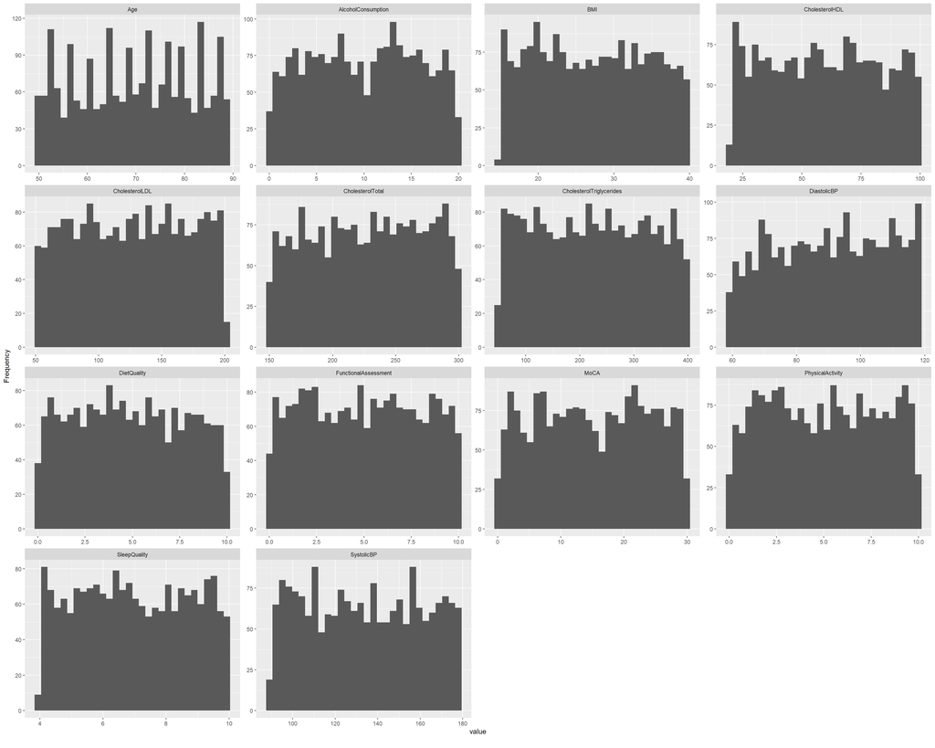

```r
plot_histogram(df)
```

```r
resultados <- data.frame(Variable = character(),
                         N_Bins = numeric(),
                         P_Value = numeric(),
                         Aceptado = character(),
                         stringsAsFactors = FALSE)
for(variable in variables_numeric){
  N_Bins <- nclass.Sturges(df[, variable])
  hist_obj <- hist(df[, variable], breaks = N_Bins, plot = FALSE)
  observed <- hist_obj$counts
  expected <- rep(sum(observed) / length(observed), length(observed))

  # Ejecutar test de Chi-cuadrado
  test_result <- chisq.test(observed, p = expected / sum(expected))
  p_value <- test_result$p.value

  # Determinar si aceptamos la hipótesis nula
  aceptado <- ifelse(p_value > 0.05, "Sí", "No")

  resultados <- rbind(resultados, data.frame(Variable = variable,
                                             N_Bins = N_Bins,
                                             P_Value = p_value,
                                             Aceptado = aceptado))
}
resultados %>% arrange(-P_Value)
```

```
##                    Variable N_Bins      P_Value Aceptado
## 1          CholesterolTotal     13 7.194309e-01       Sí
## 2               DietQuality     13 6.262007e-01       Sí
## 3              SleepQuality     13 6.127353e-01       Sí
## 4            CholesterolHDL     13 5.414346e-01       Sí
## 5      FunctionalAssessment     13 4.268170e-01       Sí
## 6            CholesterolLDL     13 3.897795e-01       Sí
## 7               DiastolicBP     13 1.515412e-01       Sí
## 8          PhysicalActivity     13 1.265261e-01       Sí
## 9                      MoCA     13 6.100806e-02       Sí
## 10               SystolicBP     13 1.135087e-02       No
## 11       AlcoholConsumption     13 1.095486e-02       No
## 12 CholesterolTriglycerides     13 6.287660e-03       No
## 13                      Age     13 1.378664e-04       No
## 14                      BMI     13 7.414357e-07       No
```

##### Distribución de variables categóricas

Ahora vamos a comprobar graficamente las variables categoricas con gráficos de barras.

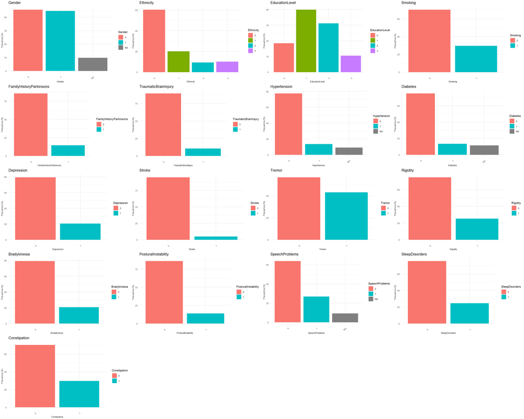

```r
# Crear una lista de gráficos con ggplot
plots_cat <- lapply(variables_factor, function(var) {
  ggplot(df, aes_string(x = var, fill = var)) +
    geom_bar(aes(y = (..count..)/sum(..count..) * 100), stat = "count") +
    labs(title = var, x = var, y = "Frecuencia (%)") +
    theme_minimal() +
    theme(
      axis.text.x = element_text(angle = 45, hjust = 1, size = 6),
      axis.text.y = element_text(size = 6),
      axis.title.x = element_text(size = 6),
      axis.title.y = element_text(size = 6),
      plot.title = element_text(size = 10),
      legend.text = element_text(size = 6),
      legend.title = element_text(size = 8),
      legend.key.size = unit(0.5,"cm"),
      plot.margin = margin(3, 3, 3, 3))
  })
do.call(grid.arrange, c(plots_cat, ncol = 4, nrow = 5))
```

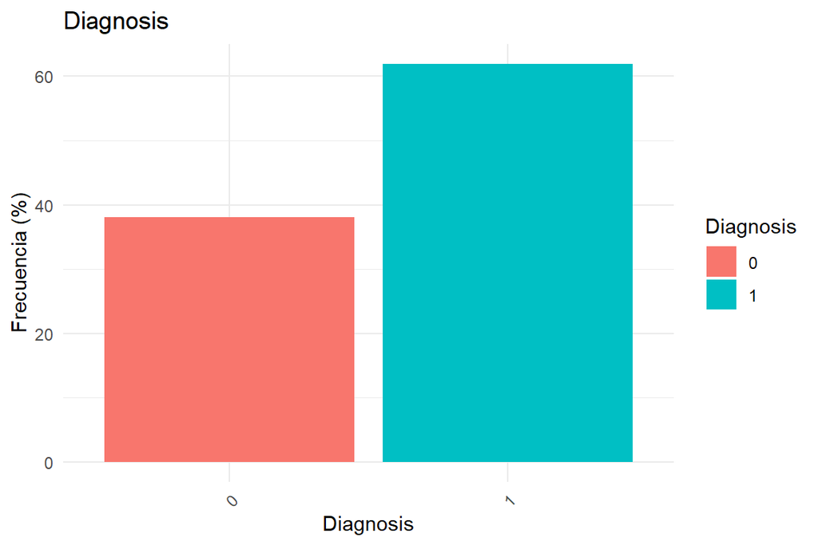

```r
ggplot(df, aes_string(x = "Diagnosis", fill = "Diagnosis")) +
    geom_bar(aes(y = (..count..)/sum(..count..) * 100), stat = "count") +
    labs(title = "Diagnosis", x = "Diagnosis", y = "Frecuencia (%)") +
    theme_minimal() +
    theme(axis.text.x = element_text(angle = 45, hjust = 1))
```

La variable objetivo (Diagnosis) parece que tiene uno de los grupos con mayor cantidad de observaciones, ajustaremos también esta variable para mantener una frecuencia equilibrada.

##### Detección de valores atípicos

Para la detección de valores atipicos podemos utilizar métodos univariantes y multivariantes. Como nos encontramos ante distribuciones que no son normales, vamos a utilizar los métodos de rango intercuartílico para los métodos univariantes y isolation forest para multivariante.

Para el método de IQR vamos a calcular el primer y tercer cuartil, el método nos dice que establecemos un rango donde deben estar todos los valores, todos aquellos que se encuentren fuera se considerarán outliers.

```r
outliers_summary <- lapply(variables_numeric, function(var) {
  Q1 <- quantile(df[[var]], 0.25, na.rm = TRUE)
  Q3 <- quantile(df[[var]], 0.75, na.rm = TRUE)
  IQR_value <- Q3 - Q1
  lower_bound <- Q1 - 1.5 * IQR_value
  upper_bound <- Q3 + 1.5 * IQR_value

  num_outliers <- sum(df[[var]] < lower_bound | df[[var]] > upper_bound, na.rm = TRUE)

  return(data.frame(Variable = var, Num_Outliers = num_outliers))
})

outliers_summary_df <- do.call(rbind, outliers_summary)
outliers_summary_df
```

```
##                    Variable Num_Outliers
## 1                       Age            0
## 2                       BMI            0
## 3        AlcoholConsumption            0
## 4          PhysicalActivity            0
## 5               DietQuality            0
## 6              SleepQuality            0
## 7                SystolicBP            0
## 8               DiastolicBP            0
## 9          CholesterolTotal            0
## 10           CholesterolLDL            0
## 11           CholesterolHDL            0
## 12 CholesterolTriglycerides            0
## 13                     MoCA            0
## 14     FunctionalAssessment            0
```

Este método nos muestra que no tenemos outliers de forma individual por variable, debemos comprobar tambien si en conjunto con todas las variables, alguna de las observaciones son outliers. Utilizaremos Isolation Forest debido a que no asume normalidad, el escalable con grandes volumenes de datos, como contra, necesitamos calibrar los parámetros y aislar los casos para comprobar si son verdaderamente outliers. Otro problema con el que nos enfrentamos es que no acepta valores nulos, como aun no hemos imputado, voy a eliminar los valores na y más adelante con la imputación podemos comparar y decidir si los valores atípicos (en caso de que existan) no debemos tenerlos encuenta.

```r
detect_outliers_solitude <- function(df, variables_numeric) {
  df_numeric <- df[ , variables_numeric, drop = FALSE]
  df_numeric <- na.omit(df_numeric)  # Manejo de NA

  iso_forest <- isolationForest$new()
  iso_forest$fit(df_numeric)

  scores <- iso_forest$predict(df_numeric)$anomaly_score

  threshold <- quantile(scores, 0.95)
  df_outliers <- df_numeric[scores > threshold, ]

  return(df_outliers)
}

outliers_solitude <- detect_outliers_solitude(df, variables_numeric)
```

```
## INFO  [11:07:28.428] Building Isolation Forest ...
## INFO  [11:07:28.541] done
## INFO  [11:07:28.546] Computing depth of terminal nodes ...
## INFO  [11:07:28.958] done
## INFO  [11:07:29.053] Completed growing isolation forest
```

```r
cat("----\n")
print("Outliers detectados por el método isolation forest")
```

```
## [1] "Outliers detectados por el método isolation forest"
```

```r
glimpse(outliers_solitude)
```

```
## Rows: 67
## Columns: 14
## $ Age                      <int> 70, 88, 80, 54, 78, 65, 79, 89, 59, 76, 66, 5…
## $ BMI                      <dbl> 15.36824, 22.46580, 15.86219, 38.58269, 37.74…
## $ AlcoholConsumption       <dbl> 2.2421353, 7.2068544, 2.4547945, 16.6198926, …
## $ PhysicalActivity         <dbl> 0.21327459, 0.70879262, 0.01878082, 2.9534793…
## $ DietQuality              <dbl> 6.498805e+00, 1.053818e-05, 7.508406e+00, 6.7…
## $ SleepQuality             <dbl> 9.929824, 9.806596, 4.857189, 5.185160, 9.146…
## $ SystolicBP               <int> 113, 153, 91, 164, 165, 95, 99, 123, 95, 168,…
## $ DiastolicBP              <int> 93, 116, 74, 103, 100, 113, 78, 117, 118, 64,…
## $ CholesterolTotal         <dbl> 287.3880, 160.2626, 159.8015, 286.9118, 214.2…
## $ CholesterolLDL           <dbl> 118.70260, 80.92793, 191.95057, 186.14486, 51…
## $ CholesterolHDL           <dbl> 85.58830, 30.19045, 20.39173, 25.92103, 24.68…
## $ CholesterolTriglycerides <dbl> 395.66265, 170.22696, 374.88044, 309.21948, 7…
## $ MoCA                     <dbl> 29.9277826, 7.3393879, 6.0650536, 28.4716596,…
## $ FunctionalAssessment     <dbl> 2.13068636, 3.05387132, 4.76592924, 0.6618045…
```

#### 1.2 Análisis de relaciones entre variables

Vamos a realizar un estudio de las variables con distintos tipos de gráfico que nos pueden ayudar a entender mejor como se distribuyen las variables e interactuan entre sí. Por último, compararemos las variables vs Diagnosis que es nuestra variable target.

##### Variables numéricas vs numéricas

Este tipo de gráficos nos pueden ayudar a entender si existen relaciones entre las variables y por ejemplo, imputar valores faltantes mediante métodos sencillos, sin tener que recurrir a la media/mediana o otros métodos más complejos.

Vamos a identificar las variables mas relacionadas entre si y solo mostraremos los gráficos para estas variables, ya que haciendo gráficos dos a dos, nos encontramos con mas de 90 combinaciones. Utilizaremos la correlacion y el MIC, ya que nos ayuda a identificar relaciones lineales y no lineales respectivamente.

```r
# Calcular la matriz de correlaciones
cor_matrix <- cor(df[ , variables_numeric, drop = FALSE], use = "pairwise.complete.obs")
cor_df <- as.data.frame(as.table(cor_matrix))
colnames(cor_df) <- c("Var1", "Var2", "Correlation")
cor_filtered <- cor_df %>%
  filter(Var1 != Var2) %>%
  arrange(desc(abs(Correlation)))
head(cor_filtered, 10)
```

```
##                        Var1                     Var2 Correlation
## 1          CholesterolTotal             SleepQuality  0.04765086
## 2              SleepQuality         CholesterolTotal  0.04765086
## 3  CholesterolTriglycerides       AlcoholConsumption -0.04241243
## 4        AlcoholConsumption CholesterolTriglycerides -0.04241243
## 5      FunctionalAssessment             SleepQuality  0.04029637
## 6              SleepQuality     FunctionalAssessment  0.04029637
## 7                      MoCA                      Age -0.04008071
## 8                       Age                     MoCA -0.04008071
## 9               DiastolicBP       AlcoholConsumption -0.04002344
## 10       AlcoholConsumption              DiastolicBP -0.04002344
```

En la tabla vemos como la correlación mas alta es del orden de ±0.04, lo que quiere decir que no existen relaciones lineales entre variables, comprobemos las relacción no lineales. El MIC nos informa si exiten relaciones no lineales si el valor es mayor a 0.4

```r
# Calcular la matriz MIC (detecta relaciones no lineales)
mic_matrix <- mine(df[ , variables_numeric, drop = FALSE],use = "pairwise.complete.obs")$MIC
mic_df <- as.data.frame(as.table(mic_matrix))
colnames(mic_df) <- c("Var1", "Var2", "MIC")
mic_filtered <- mic_df %>%
  filter(Var1 != Var2) %>%
  arrange(desc(MIC))

head(mic_filtered, 10)
```

```
##                        Var1                     Var2       MIC
## 1            CholesterolLDL               SystolicBP 0.1372241
## 2                SystolicBP           CholesterolLDL 0.1372241
## 3          CholesterolTotal       AlcoholConsumption 0.1343313
## 4        AlcoholConsumption         CholesterolTotal 0.1343313
## 5          PhysicalActivity                      BMI 0.1313015
## 6                       BMI         PhysicalActivity 0.1313015
## 7                      MoCA         PhysicalActivity 0.1301035
## 8          PhysicalActivity                     MoCA 0.1301035
## 9  CholesterolTriglycerides                      BMI 0.1293359
## 10                      BMI CholesterolTriglycerides 0.1293359
```

Vemos como no existen aparentemente relacciones entre las variables numéricas.

##### Variables categoricas vs numéricas

Veamos si existen relaciones entre variables categoricas y numéricas. Para filtrar las variables vamos a utilizar el test de Kruskal-Wallis ya que como vimos anteriormente, las variables numéricas no siguen una distribución normal. Si el test Kruskal-Wallis es positivo (es decir, p-value < 0.05), significa que al menos un grupo tiene una distribución significativamente diferente de los demás, es decir, la variable categórica afecta la distribución de la variable numerica, esto nos indica que la variable numerica podría ser un buen predictor de la variable categórica.

```r
anova_results <- list()

for (var_num in variables_numeric) {
  for (var_cat in variables_factor) {
    # Crear un subconjunto sin NAs
    df_subset <- df %>% select(all_of(c(var_num, var_cat))) %>% na.omit()

    test_result <- kruskal.test(df_subset[[var_num]] ~ df_subset[[var_cat]])
    p_value <- test_result$p.value
    test_type <- "Kruskal-Wallis"

    anova_results[[paste(var_num, var_cat, sep = "_")]] <- data.frame(
      Variable_Numerica = var_num,
      Variable_Categorica = var_cat,
      P_Value = p_value,
      Test_Usado = test_type
    )
  }
}

anova_results_df <- bind_rows(anova_results)
anova_significativos <- anova_results_df %>%
  filter(P_Value < 0.05) %>%
  arrange(Variable_Categorica) %>%
  select(Variable_Categorica, Variable_Numerica, P_Value)

print(anova_significativos)
```

```
##        Variable_Categorica  Variable_Numerica     P_Value
## 1             Bradykinesia AlcoholConsumption 0.003985573
## 2           EducationLevel                Age 0.046194409
## 3           EducationLevel               MoCA 0.021760564
## 4                Ethnicity         SystolicBP 0.003706808
## 5                Ethnicity     CholesterolLDL 0.029275564
## 6  FamilyHistoryParkinsons        DiastolicBP 0.017398386
## 7                   Gender                BMI 0.001958173
## 8           SleepDisorders                BMI 0.032732459
## 9           SpeechProblems   PhysicalActivity 0.030463524
## 10          SpeechProblems               MoCA 0.028260688
## 11    TraumaticBrainInjury   PhysicalActivity 0.043726386
## 12    TraumaticBrainInjury        DiastolicBP 0.006136646
## 13    TraumaticBrainInjury   CholesterolTotal 0.049352167
```

Vemos como hay varias hay varias variables numericas que son afectadas por la misma categoríca, si queremos imputar una de estas variables categóricas podríamos valorar utilizar una de las variables numericas de la lista. De cualquier forma, que el test haya sido positivo no significa que tenga un buen poder predictor sobre la variable.

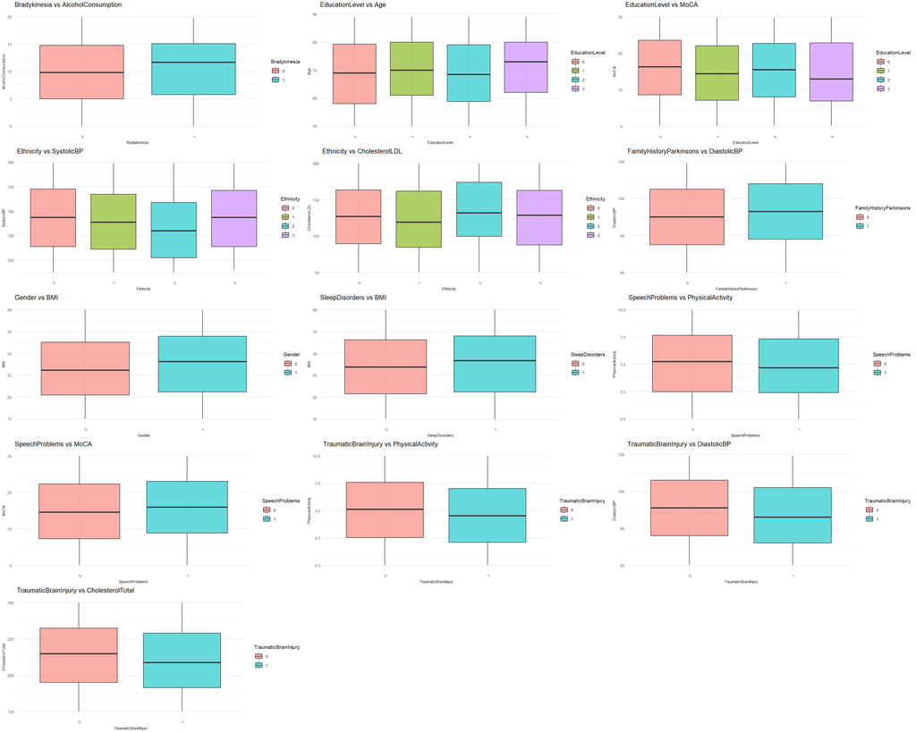

```r
plots_numerico_categorico <- list()

for (i in 1:13) {
  var_num <- anova_significativos$Variable_Numerica[i]
  var_cat <- anova_significativos$Variable_Categorica[i]

  p <- ggplot(df %>% select(all_of(c(var_num, var_cat))) %>% na.omit(),
              aes(x = .data[[var_cat]], y = .data[[var_num]], fill = .data[[var_cat]])) +
    geom_boxplot(alpha = 0.6) +
    labs(title = paste0(var_cat," vs ",var_num),x = var_cat, y = var_num) +
    theme_minimal() +
    theme(
      axis.text.x = element_text(angle = 45, hjust = 1, size = 6),
      axis.text.y = element_text(size = 6),
      axis.title.x = element_text(size = 6),
      axis.title.y = element_text(size = 6),
      plot.title = element_text(size = 10),
      legend.text = element_text(size = 6),
      legend.title = element_text(size = 8),
      legend.key.size = unit(0.5,"cm"),
      plot.margin = margin(3, 3, 3, 3))

  plots_numerico_categorico[[paste(var_num, var_cat, sep = "_")]] <- p
}

# Mostrar los gráficos en una cuadrícula
grid.arrange(grobs = plots_numerico_categorico, ncol = 3, nrow = 5)
```

##### Variables categóricas vs categóricas

Vamos a realizar un test de chi-cuadrado para ver si las variables estan asociadas dos a dos, una vez que hayamos detectado cuales estan asociadas, mostraremos la tabla de contingencia y el gráfico de barras asociado. El test chi-cuadrado nos dice que si el valor del p-valor es menor a 0.05, entonces las variables estan asociadas. Para ver si las categorías estan fuertemente relacionadas entonces podemos utilizar la V de cramer, un estadístico que nos dice que si el valor es entre 0.2 y 0.4 la relación que existe es moderada y mayor a 0.4 es fuerte.

Esto nos puede ayudar a elegir las variables a la hora de crear un modelo, ya que dos variables fuertemente relacionadas con utilizar una de ellas sería suficiente.

```r
# Obtener todas las combinaciones posibles de variables categóricas
comb_categoricas <- combn(variables_factor, 2, simplify = FALSE)
chi_results <- list()
for (comb in comb_categoricas) {
  var1 <- comb[1]
  var2 <- comb[2]
  tabla <- table(df[[var1]], df[[var2]])
  chi_test <- chisq.test(tabla)
  cramer_v <- CramerV(tabla)

  chi_results[[paste(var1, var2, sep = "_")]] <- data.frame(
    Variable1 = var1,
    Variable2 = var2,
    P_Value = chi_test$p.value,
    Chi_Squared = chi_test$statistic,
    Cramer_V = cramer_v
  )
}

chi_results_df <- bind_rows(chi_results)
chi_significativos <- chi_results_df %>%
  filter(P_Value < 0.05) %>%
  arrange(Variable1,P_Value)

print(head(chi_significativos, 10))
```

```
##                    Variable1            Variable2     P_Value Chi_Squared
## X-squared...1 EducationLevel               Tremor 0.009813765   11.385537
## X-squared...2 EducationLevel TraumaticBrainInjury 0.025581840    9.297868
## X-squared...3 EducationLevel              Smoking 0.046068640    7.997247
## X-squared...4      Ethnicity             Diabetes 0.001485744   15.427117
## X-squared...5      Ethnicity              Smoking 0.030027909    8.945238
## X-squared...6   Hypertension           Depression 0.048717795    3.885051
## X-squared...7         Tremor  PosturalInstability 0.012617300    6.221993
##                 Cramer_V
## X-squared...1 0.07354459
## X-squared...2 0.06646081
## X-squared...3 0.06163738
## X-squared...4 0.09097445
## X-squared...5 0.06518834
## X-squared...6 0.04689074
## X-squared...7 0.05575476
```

En este caso vemos en la tabla como si existe relaciones dos a dos entre variables, ya que el p-valor es inferior a 0.05. Sin embargo, el estadístico V-Cramer nos dice que ninguna de las variables tiene una relación moderada o fuerte.

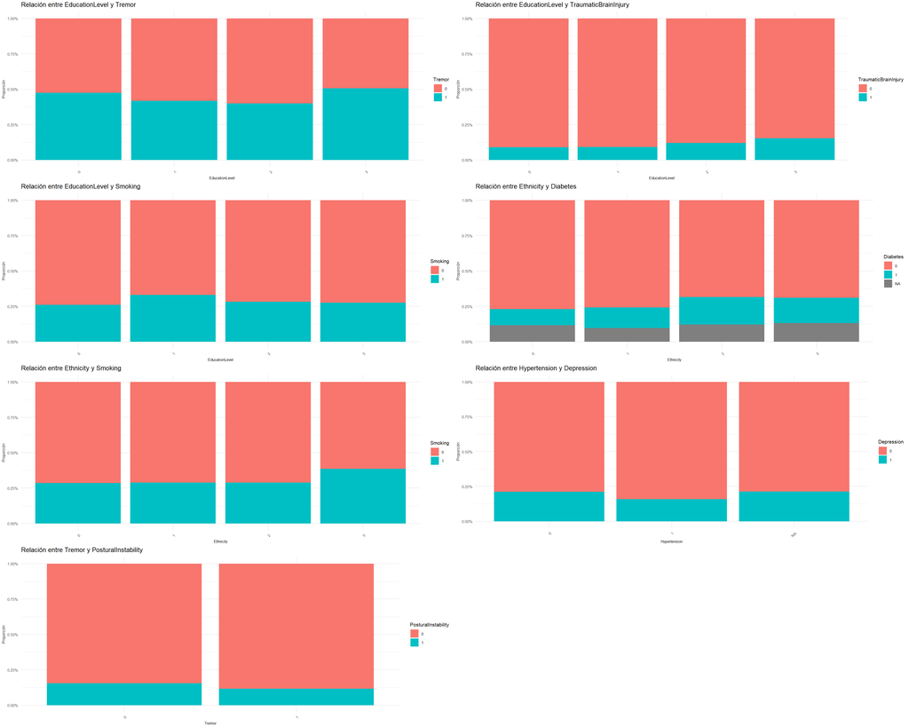

```r
plots_categoricos <- list()
top_categoricas <- head(chi_significativos, 7)

for (i in 1:nrow(top_categoricas)) {
  var1 <- top_categoricas$Variable1[i]
  var2 <- top_categoricas$Variable2[i]

  p <- ggplot(df, aes(x = .data[[var1]], fill = .data[[var2]])) +
    geom_bar(position = "fill") +
    labs(title = paste("Relación entre", var1, "y", var2),
         x = var1, y = "Proporción") +
    scale_y_continuous(labels = scales::percent_format(scale = 1)) +
    theme_minimal() +
    theme(
      axis.text.x = element_text(angle = 45, hjust = 1, size = 6),
      axis.text.y = element_text(size = 6),
      axis.title.x = element_text(size = 6),
      axis.title.y = element_text(size = 6),
      plot.title = element_text(size = 10),
      legend.text = element_text(size = 6),
      legend.title = element_text(size = 8),
      legend.key.size = unit(0.5,"cm"),
      plot.margin = margin(3, 3, 3, 3))

  plots_categoricos[[paste(var1, var2, sep = "_")]] <- p
}

grid.arrange(grobs = plots_categoricos, ncol = 2, nrow = 4)
```

##### Variables vs Diagnosis

Comprobemos ahora todas las variables vs Diagnosis, para ver si alguna de ellas tiene una relación fuerte con la variable objetivo. Para las variables numéricas utilizaremos el test de Kruskal-Wallis y para las variables categóricas el test de chi-cuadrado. En caso de que el test sea positivo, mostraremos un gráfico para ver la relación entre las variables.

```r
num_results <- list()

for (var_num in variables_numeric) {

  df_subset <- df %>% select(all_of(c(var_num, "Diagnosis"))) %>% na.omit()

  test_result <- kruskal.test(df_subset[[var_num]] ~ df_subset[["Diagnosis"]])
  p_value <- test_result$p.value

  num_results[[var_num]] <- data.frame(
    Variable = var_num,
    P_Value = p_value
  )
}

# Lista para almacenar los resultados
cat_results <- list()

for (var_cat in variables_factor) {

  tabla <- table(df[[var_cat]], df[["Diagnosis"]])
  chi_test <- chisq.test(tabla)
  cramer_v <- CramerV(tabla)

  cat_results[[var_cat]] <- data.frame(
    Variable = var_cat,
    P_Value = chi_test$p.value,
    Cramer_V = cramer_v
  )
}

results_df <- bind_rows(bind_rows(num_results) %>% mutate(Type = "Numerica"),
                        bind_rows(cat_results) %>% mutate(Type = "Categorica")) %>%
                filter(P_Value < 0.05) %>%
                arrange(Type,P_Value) %>%
                select(3,1,2,4)

results_df
```

```
##          Type             Variable      P_Value   Cramer_V
## 1  Categorica               Tremor 4.350985e-36 0.27436971
## 2  Categorica             Rigidity 2.578140e-17 0.18561127
## 3  Categorica         Bradykinesia 4.921769e-17 0.18404185
## 4  Categorica  PosturalInstability 2.037697e-11 0.14751948
## 5  Categorica           Depression 7.929752e-03 0.05908038
## 6  Categorica             Diabetes 9.003783e-03 0.06203959
## 7    Numerica FunctionalAssessment 8.707200e-25         NA
## 8    Numerica                 MoCA 1.162440e-15         NA
## 9    Numerica                  Age 3.324781e-03         NA
## 10   Numerica         SleepQuality 2.019859e-02         NA
```

Vemos como la variable Tremor con Diagnosis si parece tener una relación moderada, ya que el estadístico V-Cramer tiene un valor mayor a 0.2.

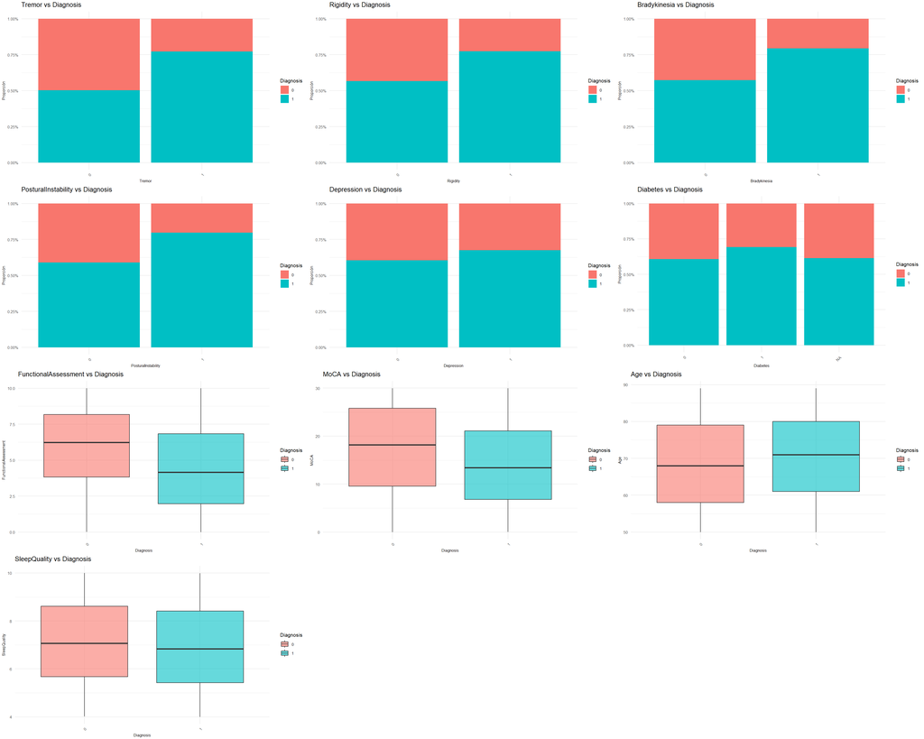

```r
plots_diagnosis <- list()  # Lista para almacenar los gráficos

# Bucle sobre cada variable filtrada
for (i in 1:nrow(results_df)) {

  var_name <- results_df$Variable[i]
  var_type <- results_df$Type[i]

  if (var_type == "Numerica") {
    # Si es numérica, hacer un boxplot
    p <- ggplot(df, aes(x = Diagnosis, y = .data[[var_name]], fill = Diagnosis)) +
      geom_boxplot(alpha = 0.6) +
      labs(title = paste(var_name, "vs Diagnosis"),
           x = "Diagnosis", y = var_name) +
      theme_minimal() +
      theme(
        axis.text.x = element_text(angle = 45, hjust = 1, size = 6),
        axis.text.y = element_text(size = 6),
        axis.title.x = element_text(size = 6),
        axis.title.y = element_text(size = 6),
        plot.title = element_text(size = 10),
        legend.text = element_text(size = 6),
        legend.title = element_text(size = 8),
        legend.key.size = unit(0.5,"cm"),
        plot.margin = margin(3, 3, 3, 3))

  } else if (var_type == "Categorica") {
    # Si es categórica, hacer un gráfico de barras apiladas
    p <- ggplot(df, aes(x = .data[[var_name]], fill = Diagnosis)) +
      geom_bar(position = "fill") +
      labs(title = paste(var_name, "vs Diagnosis"),
           x = var_name, y = "Proporción") +
      scale_y_continuous(labels = scales::percent_format(scale = 1)) +
      theme_minimal() +
      theme(
        axis.text.x = element_text(angle = 45, hjust = 1, size = 6),
        axis.text.y = element_text(size = 6),
        axis.title.x = element_text(size = 6),
        axis.title.y = element_text(size = 6),
        plot.title = element_text(size = 10),
        legend.text = element_text(size = 6),
        legend.title = element_text(size = 8),
        legend.key.size = unit(0.5,"cm"),
        plot.margin = margin(3, 3, 3, 3))
  }

  # Guardar el gráfico en la lista
  plots_diagnosis[[var_name]] <- p
}

grid.arrange(grobs = plots_diagnosis[1:length(plots_diagnosis)], ncol = 3)
```

Con los gráficos parece sobre todo las variablesTRemor, Functional Assasment y MoCA tienen mayor capacidad predictiva.

### 2. Análisis de datos faltantes

Vamos a dividir este primer apartado en varios puntos: - Detección - Métodos de imputación

#### Detección

Podemos utilizar muchas formas de mostrar los valores faltantes. Vamos a comprobar si existen valores faltantes y si hay observaciones que tienen mas de un valor faltante en el registro.

```r
# Calcular valores faltantes por columna
missing_values <- df %>%
  summarise(across(everything(), ~ sum(is.na(.)))) %>%
  pivot_longer(cols = everything(), names_to = "Variable", values_to = "Num_Faltantes") %>%
  mutate(Percentage = (Num_Faltantes / nrow(df)) * 100) %>%
  filter(Num_Faltantes > 0) %>%
  arrange(desc(Percentage))

print(missing_values)
```

```
## # A tibble: 8 × 3
##   Variable       Num_Faltantes Percentage
##   <chr>                  <int>      <dbl>
## 1 Diabetes                 241      11.4
## 2 SleepQuality             210       9.98
## 3 Gender                   205       9.74
## 4 SpeechProblems           196       9.31
## 5 Hypertension             192       9.12
## 6 CholesterolHDL           191       9.07
## 7 SystolicBP               190       9.03
## 8 DietQuality              179       8.50
```

```r
df_missing <- df %>%
mutate(Num_Faltantes = rowSums(is.na(.))) %>%
filter(Num_Faltantes >= 2) %>%
select(PatientID) %>%
pull() %>%
length() %>%
print()
```

```
## [1] 354
```

Son 354 registros que tienen más de un valor faltante, eso supone un 16% de la muestra, por lo que no podemos eliminarlos directamente, ya que perderíamos una cantidad significativa de datos. Podemos ver en la siguiente tabla como la librería mice nos ayuda a seleccionar el método de imputación más adecuado. La logica que sigue es la siguiente: - Si una variable es continua sugiere imputar por predictive mean matching. - Si la variable es categorica binaria, sugiere imputar por regresión logistica. - Si la variable es categorica con más de dos categorias, sugiere imputar a regresión logistica múltiple. - Si la variable es categorica y ordenada, entonces sugiere imputar por regresión polinómica. - Por último, si la variable tiene muchos valores faltantes, sugiere imputar mediante arboles de decisión.

```r
init <- mice(df, maxit = 0)
print(init$method)
```

```
##                PatientID                      Age                   Gender
##                       ""                       ""                 "logreg"
##                Ethnicity           EducationLevel                      BMI
##                       ""                       ""                       ""
##                  Smoking       AlcoholConsumption         PhysicalActivity
##                       ""                       ""                       ""
##              DietQuality             SleepQuality  FamilyHistoryParkinsons
##                    "pmm"                    "pmm"                       ""
##     TraumaticBrainInjury             Hypertension                 Diabetes
##                       ""                 "logreg"                 "logreg"
##               Depression                   Stroke               SystolicBP
##                       ""                       ""                    "pmm"
##              DiastolicBP         CholesterolTotal           CholesterolLDL
##                       ""                       ""                       ""
##           CholesterolHDL CholesterolTriglycerides                     MoCA
##                    "pmm"                       ""                       ""
##     FunctionalAssessment                   Tremor                 Rigidity
##                       ""                       ""                       ""
##             Bradykinesia      PosturalInstability           SpeechProblems
##                       ""                       ""                 "logreg"
##           SleepDisorders             Constipation                Diagnosis
##                       ""                       ""                       ""
```

```r
seed <- 17
set.seed(seed)

# Imputar SOLO en grupos con suficientes datos válidos y donde haya valores para muestrear
df_imp_aux <- df %>%
  group_by(Ethnicity) %>%
  mutate(Diabetes = as.integer(as.character(Diabetes)),
    Diabetes = ifelse(is.na(Diabetes),
                               base::sample(na.omit(Diabetes), 1, replace = TRUE),
                               Diabetes),
    Diabetes = as.factor(Diabetes)) %>%
  ungroup()

init <- mice(df_imp_aux, seed = seed, print = FALSE)
df_imp <- complete(init)

df_imp %>%
  summarise(across(everything(), ~ sum(is.na(.)))) %>%
  pivot_longer(cols = everything(), names_to = "Variable", values_to = "Num_Faltantes") %>%
  mutate(Percentage = (Num_Faltantes / nrow(df)) * 100) %>%
  filter(Num_Faltantes > 0) %>%
  arrange(desc(Percentage)) %>%
  print()
```

```
## # A tibble: 0 × 3
## # ℹ 3 variables: Variable <chr>, Num_Faltantes <int>, Percentage <dbl>
```

Vemos como despues de aplicar mice al conjunto de datos, ya no tenemos valores faltantes. Vamos a guardar este conjunto de datos para poder seguir con el análisis. Vamos a graficar las variables para ver como se han imputado los datos.

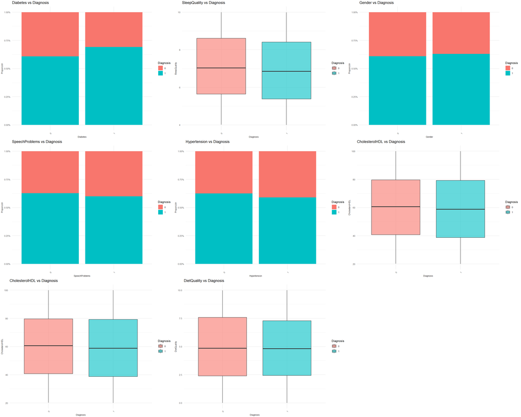

```r
plots_imputacion <- list()  # Lista para almacenar los gráficos

# Bucle sobre cada variable filtrada
for (i in 1:nrow(missing_values)) {

  var_name <- missing_values[i,1] %>% pull()
  var_type <- df[1,var_name] %>% map(class) %>% .[1] %>% unlist()

  if (var_type == "numeric") {
    # Si es numérica, hacer un boxplot
    p <- ggplot(df_imp, aes(x = Diagnosis, y = .data[[var_name]], fill = Diagnosis)) +
      geom_boxplot(alpha = 0.6) +
      labs(title = paste(var_name, "vs Diagnosis"),
           x = "Diagnosis", y = var_name) +
      theme_minimal() +
      theme(
        axis.text.x = element_text(angle = 45, hjust = 1, size = 6),
        axis.text.y = element_text(size = 6),
        axis.title.x = element_text(size = 6),
        axis.title.y = element_text(size = 6),
        plot.title = element_text(size = 10),
        legend.text = element_text(size = 6),
        legend.title = element_text(size = 8),
        legend.key.size = unit(0.5,"cm"),
        plot.margin = margin(3, 3, 3, 3))

  } else if (var_type == "factor") {
    # Si es categórica, hacer un gráfico de barras apiladas
    p <- ggplot(df_imp , aes(x = .data[[var_name]], fill = Diagnosis)) +
      geom_bar(position = "fill") +
      labs(title = paste(var_name, "vs Diagnosis"),
           x = var_name, y = "Proporción") +
      scale_y_continuous(labels = scales::percent_format(scale = 1)) +
      theme_minimal() +
      theme(
        axis.text.x = element_text(angle = 45, hjust = 1, size = 6),
        axis.text.y = element_text(size = 6),
        axis.title.x = element_text(size = 6),
        axis.title.y = element_text(size = 6),
        plot.title = element_text(size = 10),
        legend.text = element_text(size = 6),
        legend.title = element_text(size = 8),
        legend.key.size = unit(0.5,"cm"),
        plot.margin = margin(3, 3, 3, 3))
  }

  # Guardar el gráfico en la lista
  plots_imputacion[[var_name]] <- p
}

grid.arrange(grobs = plots_imputacion[1:length(plots_imputacion)], ncol = 3)
```

Vamos a repetir el proceso con el dataset una vez hemos imputado los datos, para ver si los valores atípicos han cambiado el restultado que obtuvimos anteriormente.

```r
num_results_imp <- list()

for (var_num in variables_numeric) {

  df_subset <- df_imp %>% select(all_of(c(var_num, "Diagnosis")))

  test_result <- kruskal.test(df_subset[[var_num]] ~ df_subset[["Diagnosis"]])
  p_value <- test_result$p.value

  num_results_imp[[var_num]] <- data.frame(
    Variable = var_num,
    P_Value = p_value
  )
}

# Lista para almacenar los resultados
cat_results_imp <- list()

for (var_cat in variables_factor) {

  tabla <- table(df_imp[[var_cat]], df[["Diagnosis"]])
  chi_test <- chisq.test(tabla)
  cramer_v <- CramerV(tabla)

  cat_results_imp[[var_cat]] <- data.frame(
    Variable = var_cat,
    P_Value = chi_test$p.value,
    Cramer_V = cramer_v
  )
}

results_df_imp <- bind_rows(bind_rows(num_results_imp) %>% mutate(Type = "Numerica"),
                        bind_rows(cat_results_imp) %>% mutate(Type = "Categorica")) %>%
                filter(P_Value < 0.05) %>%
                arrange(Type,P_Value) %>%
                select(3,1,2,4)

results_df_imp %>% full_join(results_df, by = c("Variable","Type"), suffix = c("_imp","_orig")) %>% select(-Type)
```

```
##                Variable  P_Value_imp Cramer_V_imp P_Value_orig Cramer_V_orig
## 1                Tremor 4.350985e-36   0.27436971 4.350985e-36    0.27436971
## 2              Rigidity 2.578140e-17   0.18561127 2.578140e-17    0.18561127
## 3          Bradykinesia 4.921769e-17   0.18404185 4.921769e-17    0.18404185
## 4   PosturalInstability 2.037697e-11   0.14751948 2.037697e-11    0.14751948
## 5            Depression 7.929752e-03   0.05908038 7.929752e-03    0.05908038
## 6              Diabetes 9.039698e-03   0.05833547 9.003783e-03    0.06203959
## 7  FunctionalAssessment 8.707200e-25           NA 8.707200e-25            NA
## 8                  MoCA 1.162440e-15           NA 1.162440e-15            NA
## 9                   Age 3.324781e-03           NA 3.324781e-03            NA
## 10         SleepQuality 3.744143e-02           NA 2.019859e-02            NA
```

En la tabla apreciamos como las variables siguen siendo las mismas y que aun habiendo cambiado los p-valores y la V-Cramer siguen siendo significativos, por lo que podemos decir que los valores atípicos no han afectado a la relación entre las variables.

### 3. Equilibrado de la variable Diagnosis

Por último vamos a realizar un equilibrado de la variable Diagnosis.

Vamos a dividir este primer apartado en varios puntos: - Evaluar el desbalanceo - Métodos de equilibrio de la muestra

#### Evaluar el desbalanceo

Ya vimos que la variable Diagnosis está desbalanceada, aproximadamente un 62% de la muestra tiene como valor 1 para Diagnosis, por lo que debemos reducir la muestra e igualarla.

```r
df_imp %>%
  group_by(Diagnosis) %>%
  summarise(Count = n()) %>%
  mutate(Percentage = round((Count / sum(Count)) * 100,2) )
```

```
## # A tibble: 2 × 3
##   Diagnosis Count Percentage
##   <fct>     <int>      <dbl>
## 1 0           801       38.0
## 2 1          1304       62.0
```

#### Método de equilibrio de la muestra

Usamos el muestreo del cubo para equilibrar la muestra reduciendo la clase mayoritaria. Así, obtenemos una muestra de 800 regristos con Diagnosis 1.

```r
df_yes <- df_imp %>% filter(Diagnosis == 1)
yes_rows <- nrow(df_yes)

# Creamos las variables indicadores para cada una de las variables de equilibrio.

# Variable que vale 1 en todas las partes (para comprobar la estimación del tamaño poblacional)
UNO = rep(1, yes_rows)

# Variables cuantitativas
X1 <- df_yes[ , variables_numeric]

# Variables cualitativas - creación de las variables indicadoras

X2 <- disjunctive(df_yes$Gender)
colnames(X2) <- levels(df_yes$Gender)

X3 <- disjunctive(df_yes$Ethnicity)
colnames(X3) <- levels(df_yes$Ethnicity)

X4 <- disjunctive(df_yes$EducationLevel)
colnames(X4) <- levels(df_yes$EducationLevel)

X5 <- disjunctive(df_yes$Smoking)
colnames(X5) <- levels(df_yes$Smoking)

X6 <- disjunctive(df_yes$FamilyHistoryParkinsons)
colnames(X6) <- levels(df_yes$FamilyHistoryParkinsons)

X7 <- disjunctive(df_yes$TraumaticBrainInjury)
colnames(X7) <- levels(df_yes$TraumaticBrainInjury)

X8 <- disjunctive(df_yes$Hypertension)
colnames(X8) <- levels(df_yes$Hypertension)

X9 <- disjunctive(df_yes$Diabetes)
colnames(X9) <- levels(df_yes$Diabetes)

X10 <- disjunctive(df_yes$Depression)
colnames(X10) <- levels(df_yes$Depression)

X11 <- disjunctive(df_yes$Stroke)
colnames(X11) <- levels(df_yes$Stroke)

X12 <- disjunctive(df_yes$Tremor)
colnames(X12) <- levels(df_yes$Tremor)

X13 <- disjunctive(df_yes$Rigidity)
colnames(X13) <- levels(df_yes$Rigidity)

X14 <- disjunctive(df_yes$Bradykinesia)
colnames(X14) <- levels(df_yes$Bradykinesia)

X15 <- disjunctive(df_yes$PosturalInstability)
colnames(X15) <- levels(df_yes$PosturalInstability)

X16 <- disjunctive(df_yes$SpeechProblems)
colnames(X16) <- levels(df_yes$SpeechProblems)

X17 <- disjunctive(df_yes$SleepDisorders)
colnames(X17) <- levels(df_yes$SleepDisorders)


# Matriz de diseño
X <- as.matrix( cbind( UNO, X1, X2, X3, X4, X5, X6, X8, X9, X10, X11, X12, X13, X14, X15, X16, X17 ) )

# Tamaño de la muestra
sample_yes_df <- 800

# Probabilidades de inclusión
pik = rep( sample_yes_df / yes_rows, yes_rows )

# extracción de la muestra
set.seed(seed)
s = samplecube(X, pik, method = 2, order = 1, comment = FALSE)

# Generación de fichero resultante
sample_yes_df_final = cbind( df_yes, s )
sample_yes_df_final <- sample_yes_df_final[ sample_yes_df_final$s == 1, ]
sample_yes_df_final$s  <- NULL
```

Veamos la calidad de la muestra obtenida:

```r
# Calidad de la muestra
Totales <- apply(X, 2, sum)
Horvitz.Thompson <- apply(X * s / pik, 2, sum)
calidad <- cbind.data.frame(Totales, Horvitz.Thompson)
calidad$Desv.Abs. <- round(calidad$Totales - calidad$Horvitz.Thompson, 2)
calidad$Desv.Rel. <- round((calidad$Totales / calidad$Horvitz.Thompson - 1) *100, 2)

formattable(calidad)
```

| Totales | Horvitz.Thompson | Desv.Abs. | Desv.Rel. |
| --- | --- | --- | --- |
| 1304.000 | 1304.000 | 0.00 | 0.00 |
| 91535.000 | 91575.030 | -40.03 | -0.04 |
| 35702.969 | 35703.235 | -0.27 | 0.00 |
| 13305.948 | 13298.291 | 7.66 | 0.06 |
| 6579.967 | 6583.265 | -3.30 | -0.05 |
| 6368.888 | 6371.407 | -2.52 | -0.04 |
| 9001.594 | 9000.594 | 1.00 | 0.01 |
| 174343.000 | 174362.730 | -19.73 | -0.01 |
| 117179.000 | 117143.210 | 35.79 | 0.03 |
| 294980.264 | 294893.400 | 86.86 | 0.03 |
| 165149.082 | 165222.911 | -73.83 | -0.04 |
| 77283.884 | 77162.672 | 121.21 | 0.16 |
| 292339.629 | 292130.715 | 208.91 | 0.07 |
| 18154.280 | 18147.974 | 6.31 | 0.03 |
| 5831.962 | 5828.616 | 3.35 | 0.06 |
| 646.000 | 645.480 | 0.52 | 0.08 |
| 658.000 | 658.520 | -0.52 | -0.08 |
| 780.000 | 780.770 | -0.77 | -0.10 |
| 275.000 | 273.840 | 1.16 | 0.42 |
| 124.000 | 123.880 | 0.12 | 0.10 |
| 125.000 | 125.510 | -0.51 | -0.41 |
| 234.000 | 233.090 | 0.91 | 0.39 |
| 528.000 | 528.120 | -0.12 | -0.02 |
| 406.000 | 405.870 | 0.13 | 0.03 |
| 136.000 | 136.920 | -0.92 | -0.67 |
| 915.000 | 916.060 | -1.06 | -0.12 |
| 389.000 | 387.940 | 1.06 | 0.27 |
| 1109.000 | 1108.400 | 0.60 | 0.05 |
| 195.000 | 195.600 | -0.60 | -0.31 |
| 1120.000 | 1121.440 | -1.44 | -0.13 |
| 184.000 | 182.560 | 1.44 | 0.79 |
| 1109.000 | 1110.030 | -1.03 | -0.09 |
| 195.000 | 193.970 | 1.03 | 0.53 |
| 1012.000 | 1008.970 | 3.03 | 0.30 |
| 292.000 | 295.030 | -3.03 | -1.03 |
| 1234.000 | 1233.910 | 0.09 | 0.01 |
| 70.000 | 70.090 | -0.09 | -0.13 |
| 602.000 | 603.100 | -1.10 | -0.18 |
| 702.000 | 700.900 | 1.10 | 0.16 |
| 892.000 | 893.240 | -1.24 | -0.14 |
| 412.000 | 410.760 | 1.24 | 0.30 |
| 957.000 | 955.180 | 1.82 | 0.19 |
| 347.000 | 348.820 | -1.82 | -0.52 |
| 1071.000 | 1072.540 | -1.54 | -0.14 |
| 233.000 | 231.460 | 1.54 | 0.67 |
| 928.000 | 929.100 | -1.10 | -0.12 |
| 376.000 | 374.900 | 1.10 | 0.29 |
| 989.000 | 989.410 | -0.41 | -0.04 |
| 315.000 | 314.590 | 0.41 | 0.13 |

Finalmente, se une la muestra de target = 1 con target = 0:

```r
sample_no_df_final <- df_imp %>% filter(Diagnosis == 0)
df_final <- bind_rows(sample_yes_df_final, sample_no_df_final)


formattable(df_final %>% group_by(Diagnosis) %>% count())
```

| Diagnosis | n |
| --- | --- |
| 0 | 801 |
| 1 | 800 |